# Exploratory Visualization on Ford GoBike Data

## by Faisal Alqahtani

## Investigation Overview

> In this invetigation, I wanted to look at the characteristics of bikes that could be used to predict the trip duration. The main foucs was on four features: duration_sec, user_type, member_birth_year and member_gender.

## Dataset Overview

> The dataset consisted of duration and attributes of approximately 17,4952 bike. The attributes included the four features mentioned above, as well as additional features such as start_time, end_time, bike_id, start_station_name and end_station_name.

## Distribution of the member gender of the subscribers and customers

> I'll start by looking at the distribution of the member gender of the Subscribers and non-subscriber. The dataset takes a large quantatiy of male subscribers and customers are than other and females, whears the number of males are above 120,000 and females are 40,000.

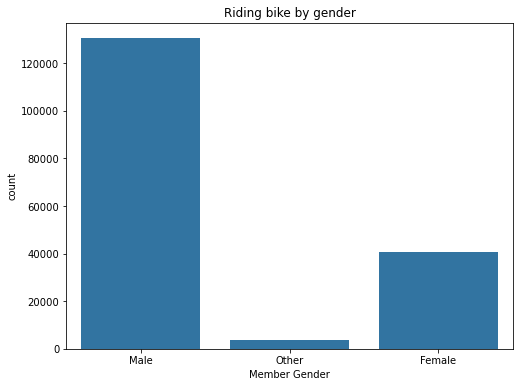

## Distribution of the trip duration according to the member gender

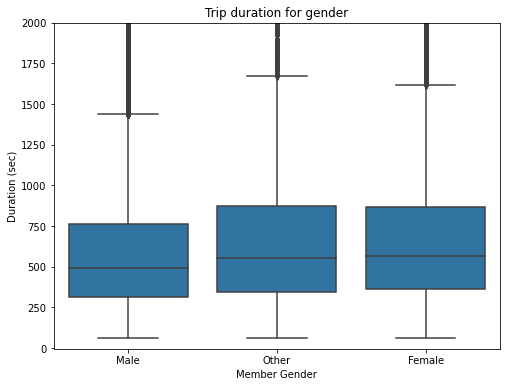

## Distribution of the number of trips in terms of weekdays and day period

- The number of trips is higher on the weekdays than weekends.
- The 'San Francisco Caltrain Station 2 (Townsend St at 4th St)' station has the highest trips in the morning & night.
- The 'Market St at 10th St' station has the highest trips in the afternoon.

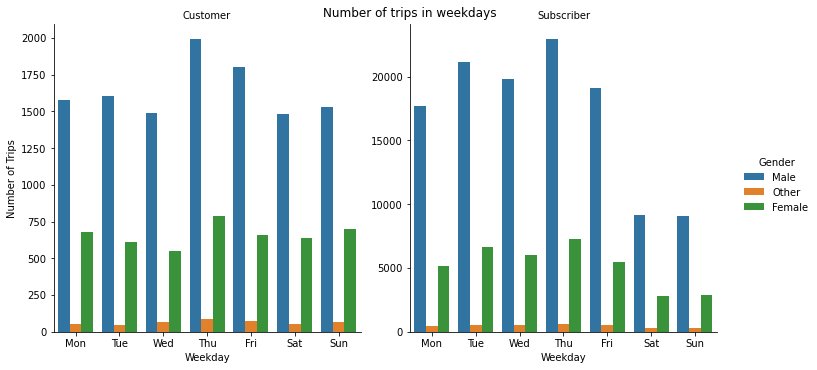

[figure not shown]